# Communication Responsiveness and Relationship Satisfaction in Long-Distance Relationships

Author

Zhiyi Cui

## About This Report

This reproducible report documents the data preparation and statistical analysis for our PSY 120L group research project. The report shows how the raw Qualtrics dataset was cleaned, how the main variables were scored, and how the final analyses were conducted in R.

## Study Overview

This study examined whether perceived communication responsiveness affects relationship satisfaction in an imagined long-distance romantic relationship. Participants read either a high-responsiveness or low-responsiveness vignette. Relationship satisfaction was measured using the Relationship Assessment Scale. We also examined whether the effect of responsiveness differed based on attachment anxiety and prior long-distance relationship experience.

The primary analyses were two 2 × 2 between-subjects ANOVAs:

1. Communication Responsiveness × Attachment Anxiety on Relationship Satisfaction
2. Communication Responsiveness × Prior LDR Experience on Relationship Satisfaction

## Setup and Software Environment

The report first sets global chunk options and loads the packages used for data preparation, descriptive statistics, ANOVAs, estimated means, and figures.

```r
knitr::opts_chunk$set(
  echo = TRUE,
  message = FALSE,
  warning = FALSE
)

options(stringsAsFactors = FALSE)
```

**load packages**

```r
library(tidyverse)
library(psych)
library(afex)
library(emmeans)
```

## Data Source and Analysis Dataset

The raw Qualtrics file was imported from the local data folder.

**Read in Your Data**

```r
data <- read_csv("data/LongDistanceRelationship.csv")

dim(data)
```

```
[1] 226  39
```

```r
names(data)
```

```
 [1] "StartDate"             "EndDate"               "Duration (in seconds)"
 [4] "Finished"              "RecordedDate"          "Consent Form"
 [7] "MC1"                   "RAS1"                  "RAS2"
[10] "RAS3"                  "RAS4"                  "RAS5"
[13] "RAS6"                  "RAS7"                  "AAS1"
[16] "AAS2"                  "AAS3"                  "AAS4"
[19] "AAS5"                  "AAS6"                  "AAS7"
[22] "AAS8"                  "AAS9"                  "AAS10"
[25] "AAS11"                 "AAS12"                 "AAS13"
[28] "AAS14"                 "AAS15"                 "AAS16"
[31] "AAS17"                 "AAS18"                 "Age"
[34] "Age_8_TEXT"            "Gender"                "Gender _5_TEXT"
[37] "Relationship_exp"      "Relationship_length"   "Condition"
```

```r
head(data)
```

| StartDate | EndDate | Duration (in seconds) | Finished | RecordedDate | Consent Form | MC1 | RAS1 | RAS2 | RAS3 | RAS4 | RAS5 | RAS6 | RAS7 | AAS1 | AAS2 | AAS3 | AAS4 | AAS5 | AAS6 | AAS7 | AAS8 | AAS9 | AAS10 | AAS11 | AAS12 | AAS13 | AAS14 | AAS15 | AAS16 | … |
| --- | --- | --- | --- | --- | --- | --- | --- | --- | --- | --- | --- | --- | --- | --- | --- | --- | --- | --- | --- | --- | --- | --- | --- | --- | --- | --- | --- | --- | --- | --- |
| 4/30/2026 18:47 | 4/30/2026 18:58 | 695 | 1 | 4/30/2026 18:58 | 1 | 1 | 1 | 1 | 1 | 4 | 1 | 1 | 4 | 4 | 2 | 2 | 3 | 2 | 4 | 4 | 4 | 2 | 4 | 2 | 2 | 3 | 4 | 2 | 2 | … |
| 4/30/2026 19:09 | 4/30/2026 22:44 | 12932 | 1 | 4/30/2026 22:44 | 1 | 6 | 5 | 1 | 4 | 1 | 5 | 5 | 1 | 1 | 1 | 1 | 5 | 1 | 3 | 5 | 1 | 3 | 1 | 4 | 1 | 4 | 3 | 2 | 2 | … |
| 4/30/2026 22:59 | 4/30/2026 23:11 | 707 | 1 | 4/30/2026 23:11 | 1 | 6 | 5 | 5 | 5 | 1 | 5 | 5 | 2 | 3 | 2 | 4 | 4 | 3 | 3 | 3 | 4 | 2 | 2 | 3 | 3 | 4 | 4 | 2 | 2 | … |
| 4/30/2026 19:19 | 4/30/2026 23:32 | 15216 | 1 | 4/30/2026 23:32 | 1 | 4 | 2 | 2 | 2 | 3 | 2 | 4 | 4 | 1 | 1 | 4 | 5 | 1 | 1 | 4 | 1 | 1 | 1 | 3 | 2 | 5 | 4 | 2 | 1 | … |
| 4/30/2026 23:32 | 4/30/2026 23:33 | 26 | 1 | 4/30/2026 23:33 | 2 | NA | NA | NA | NA | NA | NA | NA | NA | NA | NA | NA | NA | NA | NA | NA | NA | NA | NA | NA | NA | NA | NA | NA | NA | … |
| 5/5/2026 18:58 | 5/5/2026 19:05 | 417 | 1 | 5/5/2026 19:05 | 1 | 3 | 2 | 2 | 2 | 3 | 2 | 4 | 3 | 2 | 2 | 3 | 3 | 4 | 3 | 2 | 4 | 2 | 4 | 4 | 2 | 4 | 4 | 2 | 2 | … |

**Clean Raw Data**

```r
study_data <- data %>%
  slice(-1, -2)
```

## Variable Preparation

This section identifies the variables needed for the analyses, recodes the experimental condition, computes scale scores, checks missingness, creates grouping variables, and summarizes internal consistency.

**Select and Verify Analysis Dataset**

Only the variables needed for scoring, descriptive statistics, and planned analyses were retained. Numeric conversion was applied to the survey items and demographic codes.

```r
study_vars <- c(
  "Condition",
  "MC1",
  "RAS1", "RAS2", "RAS3", "RAS4", "RAS5", "RAS6", "RAS7",
  "AAS1", "AAS2", "AAS3", "AAS4", "AAS5", "AAS6",
  "AAS7", "AAS8", "AAS9", "AAS10", "AAS11", "AAS12",
  "AAS13", "AAS14", "AAS15", "AAS16", "AAS17", "AAS18",
  "Age",
  "Gender",
  "Relationship_exp",
  "Relationship_length"
)
```

```r
length(study_vars)
```

```
[1] 31
```

```r
study_data <- study_data[, study_vars]

study_data <- study_data %>%
  mutate(
    across(-Condition, as.numeric),
    Condition = factor(Condition)
  )

summary(study_data)
```

```
 Condition       MC1             RAS1            RAS2            RAS3
 High:107   Min.   :1.000   Min.   :1.000   Min.   :1.000   Min.   :1.000
 Low :109   1st Qu.:2.000   1st Qu.:2.000   1st Qu.:2.000   1st Qu.:2.000
 NAs :  8   Median :4.000   Median :3.000   Median :3.000   Median :3.000
            Mean   :3.723   Mean   :3.222   Mean   :3.117   Mean   :3.205
            3rd Qu.:5.000   3rd Qu.:4.000   3rd Qu.:4.000   3rd Qu.:4.000
            Max.   :6.000   Max.   :5.000   Max.   :5.000   Max.   :5.000
            NAs    :36      NAs    :53      NAs    :53      NAs    :53
      RAS4            RAS5            RAS6            RAS7
 Min.   :1.000   Min.   :1.000   Min.   :1.000   Min.   :1.000
 1st Qu.:2.000   1st Qu.:2.000   1st Qu.:3.000   1st Qu.:2.000
 Median :2.000   Median :3.000   Median :4.000   Median :3.000
 Mean   :2.509   Mean   :3.041   Mean   :3.865   Mean   :2.895
 3rd Qu.:3.000   3rd Qu.:4.000   3rd Qu.:5.000   3rd Qu.:4.000
 Max.   :5.000   Max.   :5.000   Max.   :5.000   Max.   :5.000
 NAs    :53      NAs    :53      NAs    :53      NAs    :53
      AAS1            AAS2            AAS3            AAS4           AAS5
 Min.   :1.000   Min.   :1.000   Min.   :1.000   Min.   :1.00   Min.   :1.000
 1st Qu.:2.000   1st Qu.:2.000   1st Qu.:2.000   1st Qu.:3.00   1st Qu.:2.000
 Median :3.000   Median :2.000   Median :3.000   Median :3.00   Median :3.000
 Mean   :3.208   Mean   :2.512   Mean   :2.976   Mean   :3.28   Mean   :3.196
 3rd Qu.:4.000   3rd Qu.:3.000   3rd Qu.:4.000   3rd Qu.:4.00   3rd Qu.:4.000
 Max.   :5.000   Max.   :5.000   Max.   :5.000   Max.   :5.00   Max.   :5.000
 NAs    :56      NAs    :56      NAs    :56      NAs    :56     NAs    :56
      AAS6            AAS7            AAS8           AAS9           AAS10
 Min.   :1.000   Min.   :1.000   Min.   :1.00   Min.   :1.000   Min.   :1.000
 1st Qu.:2.750   1st Qu.:2.000   1st Qu.:2.00   1st Qu.:2.000   1st Qu.:2.000
 Median :3.000   Median :3.000   Median :3.00   Median :3.000   Median :3.000
 Mean   :3.238   Mean   :3.119   Mean   :2.78   Mean   :2.774   Mean   :2.845
 3rd Qu.:4.000   3rd Qu.:4.000   3rd Qu.:4.00   3rd Qu.:4.000   3rd Qu.:4.000
 Max.   :5.000   Max.   :5.000   Max.   :5.00   Max.   :5.000   Max.   :5.000
 NAs    :56      NAs    :56      NAs    :56     NAs    :56      NAs    :56
     AAS11           AAS12           AAS13           AAS14
 Min.   :1.000   Min.   :1.000   Min.   :1.000   Min.   :1.000
 1st Qu.:2.000   1st Qu.:2.000   1st Qu.:2.000   1st Qu.:3.000
 Median :2.000   Median :2.000   Median :3.000   Median :4.000
 Mean   :2.524   Mean   :2.337   Mean   :3.133   Mean   :3.373
 3rd Qu.:3.000   3rd Qu.:3.000   3rd Qu.:4.000   3rd Qu.:4.000
 Max.   :5.000   Max.   :5.000   Max.   :5.000   Max.   :5.000
 NAs    :58      NAs    :58      NAs    :58      NAs    :58
     AAS15           AAS16           AAS17           AAS18
 Min.   :1.000   Min.   :1.000   Min.   :1.000   Min.   :1.000
 1st Qu.:2.000   1st Qu.:2.000   1st Qu.:3.000   1st Qu.:2.000
 Median :2.500   Median :3.000   Median :4.000   Median :3.000
 Mean   :2.711   Mean   :2.958   Mean   :3.729   Mean   :2.753
 3rd Qu.:3.000   3rd Qu.:4.000   3rd Qu.:4.000   3rd Qu.:3.000
 Max.   :5.000   Max.   :5.000   Max.   :5.000   Max.   :5.000
 NAs    :58      NAs    :58      NAs    :58      NAs    :58
      Age            Gender      Relationship_exp Relationship_length
 Min.   :1.000   Min.   :1.000   Min.   :0.0000   Min.   :1.000
 1st Qu.:3.000   1st Qu.:1.000   1st Qu.:0.0000   1st Qu.:2.000
 Median :4.000   Median :1.000   Median :1.0000   Median :5.000
 Mean   :4.194   Mean   :1.297   Mean   :0.5758   Mean   :3.779
 3rd Qu.:5.000   3rd Qu.:1.000   3rd Qu.:1.0000   3rd Qu.:5.000
 Max.   :8.000   Max.   :5.000   Max.   :1.0000   Max.   :5.000
 NAs    :59      NAs    :59      NAs    :59       NAs    :129
```

```r
names(study_data)
```

```
 [1] "Condition"           "MC1"                 "RAS1"
 [4] "RAS2"                "RAS3"                "RAS4"
 [7] "RAS5"                "RAS6"                "RAS7"
[10] "AAS1"                "AAS2"                "AAS3"
[13] "AAS4"                "AAS5"                "AAS6"
[16] "AAS7"                "AAS8"                "AAS9"
[19] "AAS10"               "AAS11"               "AAS12"
[22] "AAS13"               "AAS14"               "AAS15"
[25] "AAS16"               "AAS17"               "AAS18"
[28] "Age"                 "Gender"              "Relationship_exp"
[31] "Relationship_length"
```

**Recode Communication Responsiveness Condition**

Condition labels were changed from short codes to reader-friendly labels for tables and figures.

```r
study_data <- study_data %>%
  mutate(
    Condition = factor(
      Condition,
      levels = c("Low", "High"),
      labels = c("Low Responsiveness",
                 "High Responsiveness")
    )
  )

study_data %>%
  count(Condition)
```

| Condition | n |
| --- | --- |
| Low Responsiveness | 109 |
| High Responsiveness | 107 |
| NA | 8 |

**Create Participant ID**

A row-based participant ID was created so that each response could be used as a unique case in the ANOVA models.

```r
study_data <- study_data %>%
  mutate(id = row_number())
study_data %>%
  select(id) %>%
  head()
```

| id |
| --- |
| 1 |
| 2 |
| 3 |
| 4 |
| 5 |
| 6 |

**Create and Check Relationship Satisfaction Items**

RAS items 4 and 7 were reverse-coded before the seven items were averaged. Higher scores indicate greater relationship satisfaction.

```r
study_data <- study_data %>%
  mutate(
    RAS4r = 6 - RAS4,
    RAS7r = 6 - RAS7
  )

ras_items <- c("RAS1", "RAS2", "RAS3", "RAS4r", "RAS5", "RAS6", "RAS7r")

study_data <- study_data %>%
  mutate(
    relationship_satisfaction = rowMeans(across(all_of(ras_items)), na.rm = TRUE)
  )

summary(study_data$relationship_satisfaction)
```

```
   Min. 1st Qu.  Median    Mean 3rd Qu.    Max.     NAs
  1.000   2.571   3.286   3.292   4.000   5.000      53
```

**Define Attachment Subscales**

The Adult Attachment Scale items were grouped into attachment-anxiety and attachment-avoidance subscales. Higher scores indicate greater attachment insecurity.

```r
anxiety_items <- c(
  "AAS3", "AAS4", "AAS9",
  "AAS10", "AAS11", "AAS15"
)

avoidance_items <- c(
  "AAS1", "AAS2", "AAS5", "AAS6",
  "AAS7", "AAS8", "AAS12", "AAS13",
  "AAS14", "AAS16", "AAS17", "AAS18"
)

setNames(anxiety_items %in% names(study_data), anxiety_items)
```

```
 AAS3  AAS4  AAS9 AAS10 AAS11 AAS15
 TRUE  TRUE  TRUE  TRUE  TRUE  TRUE
```

```r
setNames(avoidance_items %in% names(study_data), avoidance_items)
```

```
 AAS1  AAS2  AAS5  AAS6  AAS7  AAS8 AAS12 AAS13 AAS14 AAS16 AAS17 AAS18
 TRUE  TRUE  TRUE  TRUE  TRUE  TRUE  TRUE  TRUE  TRUE  TRUE  TRUE  TRUE
```

**Compute Attachment Scores**

Composite scores were created by averaging the relevant items for each participant.

```r
study_data <- study_data %>%
  mutate(
    relationship_satisfaction =
      rowMeans(across(all_of(ras_items)), na.rm = TRUE),

    attachment_anxiety =
      rowMeans(across(all_of(anxiety_items)), na.rm = TRUE),

    attachment_avoidance =
      rowMeans(across(all_of(avoidance_items)), na.rm = TRUE)
  )

summary(study_data$relationship_satisfaction)
```

```
   Min. 1st Qu.  Median    Mean 3rd Qu.    Max.     NAs
  1.000   2.571   3.286   3.292   4.000   5.000      53
```

```r
summary(study_data$attachment_anxiety)
```

```
   Min. 1st Qu.  Median    Mean 3rd Qu.    Max.     NAs
  1.333   2.500   2.833   2.853   3.167   4.333      56
```

```r
summary(study_data$attachment_avoidance)
```

```
   Min. 1st Qu.  Median    Mean 3rd Qu.    Max.     NAs
  1.917   2.833   3.000   3.024   3.250   4.333      56
```

**Check Missingness**

Missingness was checked before running the analyses so that the final model sample sizes could be interpreted clearly.

```r
mean(is.na(study_data$relationship_satisfaction))
```

```
[1] 0.2366071
```

```r
mean(is.na(study_data$attachment_anxiety))
```

```
[1] 0.25
```

```r
mean(is.na(study_data$attachment_avoidance))
```

```
[1] 0.25
```

**Create Attachment Anxiety Groups**

Attachment anxiety was divided at the sample median to create low-anxiety and high-anxiety groups for the planned 2 × 2 ANOVA.

```r
anxiety_median <- median(
  study_data$attachment_anxiety,
  na.rm = TRUE
)

study_data <- study_data %>%
  mutate(
    anxiety_msplit = if_else(
      attachment_anxiety <= anxiety_median,
      "Low Anxiety",
      "High Anxiety"
    )
  )

study_data <- study_data %>%
  mutate(
    anxiety_msplit = factor(
      anxiety_msplit,
      levels = c(
        "Low Anxiety",
        "High Anxiety"
      )
    )
  )

study_data %>%
  count(anxiety_msplit) %>%
  knitr::kable()
```

| anxiety_msplit | n |
| --- | --- |
| Low Anxiety | 99 |
| High Anxiety | 69 |
| NA | 56 |

**Check Reliability**

Internal consistency was checked for the relationship-satisfaction scale and attachment subscales using Cronbach’s alpha.

```r
psych::alpha(
  study_data %>%
    select(all_of(ras_items))
)
```

```
Reliability analysis
Call: psych::alpha(x = study_data %>% select(all_of(ras_items)))

  raw_alpha std.alpha G6(smc) average_r S/N    ase mean sd median_r
      0.92      0.92    0.92      0.61  11 0.0081  3.3  1     0.54

    95% confidence boundaries
         lower alpha upper
Feldt      0.9  0.92  0.93
Duhachek   0.9  0.92  0.93

 Reliability if an item is dropped:
      raw_alpha std.alpha G6(smc) average_r  S/N alpha se var.r med.r
RAS1       0.89      0.89    0.90      0.58  8.2   0.0107 0.024  0.54
RAS2       0.89      0.89    0.89      0.57  7.9   0.0111 0.020  0.54
RAS3       0.89      0.89    0.90      0.57  8.1   0.0108 0.024  0.54
RAS4r      0.92      0.92    0.92      0.65 11.2   0.0078 0.029  0.60
RAS5       0.90      0.89    0.90      0.58  8.2   0.0105 0.027  0.52
RAS6       0.92      0.91    0.92      0.64 10.8   0.0085 0.027  0.54
RAS7r      0.92      0.92    0.92      0.66 11.4   0.0078 0.026  0.60

 Item statistics
        n raw.r std.r r.cor r.drop mean  sd
RAS1  171  0.90  0.89  0.89   0.85  3.2 1.4
RAS2  171  0.92  0.91  0.93   0.88  3.1 1.3
RAS3  171  0.91  0.90  0.90   0.86  3.2 1.3
RAS4r 171  0.69  0.70  0.61   0.59  3.5 1.2
RAS5  171  0.89  0.89  0.88   0.84  3.0 1.2
RAS6  171  0.71  0.72  0.65   0.62  3.9 1.1
RAS7r 171  0.68  0.69  0.61   0.58  3.1 1.2

Non missing response frequency for each item
         1    2    3    4    5 miss
RAS1  0.15 0.17 0.21 0.24 0.23 0.24
RAS2  0.13 0.22 0.22 0.25 0.18 0.24
RAS3  0.08 0.27 0.19 0.26 0.19 0.24
RAS4r 0.05 0.18 0.23 0.32 0.22 0.24
RAS5  0.10 0.28 0.26 0.19 0.16 0.24
RAS6  0.04 0.05 0.27 0.30 0.35 0.24
RAS7r 0.07 0.25 0.35 0.17 0.16 0.24
```

```r
psych::alpha(
  study_data %>%
    select(all_of(anxiety_items))
)
```

```
Some items ( AAS3 AAS4 ) were negatively correlated with the first principal component and
probably should be reversed.
To do this, run the function again with the 'check.keys=TRUE' option
```

```
Reliability analysis
Call: psych::alpha(x = study_data %>% select(all_of(anxiety_items)))

  raw_alpha std.alpha G6(smc) average_r  S/N   ase mean   sd median_r
      0.19      0.18     0.3     0.035 0.22 0.084  2.9 0.46    0.071

    95% confidence boundaries
         lower alpha upper
Feldt     0.02  0.19  0.35
Duhachek  0.03  0.19  0.36

 Reliability if an item is dropped:
      raw_alpha std.alpha G6(smc) average_r     S/N alpha se var.r  med.r
AAS3     0.1768    0.1437    0.20    0.0325  0.1678    0.084 0.032  0.084
AAS4     0.2578    0.2353    0.27    0.0580  0.3077    0.077 0.027  0.108
AAS9     0.1116    0.1187    0.24    0.0262  0.1346    0.094 0.049  0.052
AAS10    0.1853    0.1793    0.27    0.0419  0.2185    0.086 0.045  0.065
AAS11   -0.0067   -0.0095    0.17   -0.0019 -0.0094    0.108 0.064 -0.099
AAS15    0.2205    0.2186    0.33    0.0530  0.2798    0.083 0.060  0.076

 Item statistics
        n raw.r std.r r.cor r.drop mean   sd
AAS3  168  0.41  0.45  0.34  0.065  3.0 0.96
AAS4  168  0.30  0.36  0.16 -0.043  3.3 0.95
AAS9  168  0.49  0.48  0.28  0.141  2.8 1.01
AAS10 168  0.47  0.42  0.18  0.060  2.8 1.15
AAS11 166  0.61  0.58  0.43  0.246  2.5 1.13
AAS15 166  0.37  0.37  0.04  0.013  2.7 1.01

Non missing response frequency for each item
         1    2    3    4    5 miss
AAS3  0.05 0.29 0.33 0.29 0.04 0.25
AAS4  0.05 0.13 0.39 0.36 0.07 0.25
AAS9  0.08 0.36 0.28 0.24 0.03 0.25
AAS10 0.13 0.29 0.24 0.27 0.07 0.25
AAS11 0.20 0.33 0.25 0.17 0.04 0.26
AAS15 0.07 0.43 0.27 0.19 0.05 0.26
```

```r
psych::alpha(
  study_data %>%
    select(all_of(avoidance_items))
)
```

```
Some items ( AAS7 AAS13 AAS14 AAS17 ) were negatively correlated with the first principal component and
probably should be reversed.
To do this, run the function again with the 'check.keys=TRUE' option
```

```
Reliability analysis
Call: psych::alpha(x = study_data %>% select(all_of(avoidance_items)))

  raw_alpha std.alpha G6(smc) average_r  S/N   ase mean   sd median_r
      0.31       0.3    0.47     0.035 0.44 0.066    3 0.36    0.002

    95% confidence boundaries
         lower alpha upper
Feldt     0.17  0.31  0.44
Duhachek  0.18  0.31  0.44

 Reliability if an item is dropped:
      raw_alpha std.alpha G6(smc) average_r  S/N alpha se var.r   med.r
AAS1       0.23      0.23    0.42     0.027 0.31    0.075 0.044 -0.0095
AAS2       0.24      0.23    0.40     0.026 0.29    0.075 0.040 -0.0095
AAS5       0.16      0.16    0.35     0.017 0.19    0.083 0.037 -0.0101
AAS6       0.15      0.14    0.32     0.015 0.17    0.083 0.035 -0.0101
AAS7       0.43      0.41    0.53     0.058 0.68    0.054 0.042  0.0409
AAS8       0.25      0.24    0.41     0.028 0.32    0.073 0.042 -0.0101
AAS12      0.33      0.32    0.49     0.041 0.47    0.066 0.049 -0.0101
AAS13      0.38      0.37    0.50     0.051 0.59    0.059 0.040  0.0409
AAS14      0.35      0.34    0.49     0.045 0.51    0.062 0.045  0.0249
AAS16      0.24      0.24    0.41     0.028 0.32    0.074 0.039 -0.0101
AAS17      0.35      0.35    0.50     0.047 0.54    0.062 0.045  0.0409
AAS18      0.29      0.29    0.46     0.036 0.42    0.069 0.046 -0.0101

 Item statistics
        n raw.r std.r  r.cor r.drop mean   sd
AAS1  168 0.471 0.447  0.369  0.235  3.2 1.12
AAS2  168 0.460 0.460  0.438  0.255  2.5 0.92
AAS5  168 0.591 0.582  0.638  0.384  3.2 1.08
AAS6  168 0.612 0.608  0.696  0.423  3.2 1.01
AAS7  168 0.045 0.023 -0.241 -0.232  3.1 1.16
AAS8  168 0.445 0.430  0.375  0.191  2.8 1.15
AAS12 166 0.238 0.265  0.053  0.015  2.3 0.94
AAS13 166 0.098 0.126 -0.072 -0.132  3.1 0.97
AAS14 166 0.184 0.210  0.018 -0.046  3.4 0.96
AAS16 166 0.459 0.428  0.390  0.221  3.0 1.08
AAS17 166 0.144 0.177 -0.045 -0.072  3.7 0.90
AAS18 166 0.331 0.320  0.181  0.099  2.8 0.99

Non missing response frequency for each item
         1    2    3    4    5 miss
AAS1  0.06 0.24 0.24 0.35 0.11 0.25
AAS2  0.11 0.45 0.29 0.15 0.01 0.25
AAS5  0.05 0.25 0.23 0.38 0.09 0.25
AAS6  0.05 0.20 0.29 0.39 0.07 0.25
AAS7  0.06 0.32 0.19 0.32 0.12 0.25
AAS8  0.13 0.34 0.21 0.26 0.06 0.25
AAS12 0.19 0.42 0.27 0.12 0.01 0.26
AAS13 0.04 0.22 0.36 0.32 0.06 0.26
AAS14 0.01 0.23 0.21 0.47 0.08 0.26
AAS16 0.06 0.34 0.25 0.27 0.08 0.26
AAS17 0.01 0.11 0.18 0.54 0.16 0.26
AAS18 0.10 0.31 0.34 0.22 0.02 0.26
```

## Descriptive Statistics

Descriptive statistics summarize the main continuous variables and the sizes of the categorical groups used in the analyses.

```r
psych::describe(
  study_data %>%
    select(MC1, relationship_satisfaction, attachment_anxiety, attachment_avoidance)
)
```

|  | vars | n | mean | sd | median | trimmed | mad | min | max | range | skew | kurtosis | se |
| --- | --- | --- | --- | --- | --- | --- | --- | --- | --- | --- | --- | --- | --- |
| MC1 | 1 | 188 | 3.723404 | 1.6475829 | 4.000000 | 3.763158 | 1.48260 | 1.000000 | 6.000000 | 5.000000 | -0.09848510 | -1.3684009 | 0.12016234 |
| relationship_satisfaction | 2 | 171 | 3.292398 | 1.0062008 | 3.285714 | 3.298227 | 1.05900 | 1.000000 | 5.000000 | 4.000000 | -0.04427859 | -0.9568797 | 0.07694610 |
| attachment_anxiety | 3 | 168 | 2.852679 | 0.4606951 | 2.833333 | 2.835172 | 0.49420 | 1.333333 | 4.333333 | 3.000000 | 0.34364120 | 0.9014919 | 0.03554340 |
| attachment_avoidance | 4 | 168 | 3.024306 | 0.3568727 | 3.000000 | 3.029412 | 0.37065 | 1.916667 | 4.333333 | 2.416667 | -0.14968644 | 1.3841840 | 0.02753333 |

```r
study_data %>%
  count(Condition)
```

| Condition | n |
| --- | --- |
| Low Responsiveness | 109 |
| High Responsiveness | 107 |
| NA | 8 |

**Continuous Variables**

```r
psych::describe(
  study_data %>%
    select(
      relationship_satisfaction,
      attachment_anxiety,
      attachment_avoidance
    )
) %>%
  knitr::kable(digits = 2)
```

|  | vars | n | mean | sd | median | trimmed | mad | min | max | range | skew | kurtosis | se |
| --- | --- | --- | --- | --- | --- | --- | --- | --- | --- | --- | --- | --- | --- |
| relationship_satisfaction | 1 | 171 | 3.29 | 1.01 | 3.29 | 3.30 | 1.06 | 1.00 | 5.00 | 4.00 | -0.04 | -0.96 | 0.08 |
| attachment_anxiety | 2 | 168 | 2.85 | 0.46 | 2.83 | 2.84 | 0.49 | 1.33 | 4.33 | 3.00 | 0.34 | 0.90 | 0.04 |
| attachment_avoidance | 3 | 168 | 3.02 | 0.36 | 3.00 | 3.03 | 0.37 | 1.92 | 4.33 | 2.42 | -0.15 | 1.38 | 0.03 |

**Categorical Variables**

```r
study_data %>%
  count(Condition) %>%
  knitr::kable()
```

| Condition | n |
| --- | --- |
| Low Responsiveness | 109 |
| High Responsiveness | 107 |
| NA | 8 |

```r
study_data %>%
  count(anxiety_msplit) %>%
  knitr::kable()
```

| anxiety_msplit | n |
| --- | --- |
| Low Anxiety | 99 |
| High Anxiety | 69 |
| NA | 56 |

## Manipulation Check

The manipulation check tested whether participants perceived the partner as more responsive in the high-responsiveness condition than in the low-responsiveness condition.

```r
mc_summary <- study_data %>%
  filter(
    !is.na(Condition),
    !is.na(MC1)
  ) %>%
  group_by(Condition) %>%
  summarise(
    n = n(),
    M = mean(MC1),
    SD = sd(MC1),
    .groups = "drop"
  )

mc_summary %>%
  knitr::kable(digits = 2)
```

| Condition | n | M | SD |
| --- | --- | --- | --- |
| Low Responsiveness | 97 | 2.67 | 1.25 |
| High Responsiveness | 91 | 4.85 | 1.23 |

```r
t.test(
  MC1 ~ Condition,
  data = study_data
)
```

```
    Welch Two Sample t-test

data:  MC1 by Condition
t = -12.046, df = 185.56, p-value < 2.2e-16
alternative hypothesis: true difference in means between group Low Responsiveness and group High Responsiveness is not equal to 0
95 percent confidence interval:
 -2.532447 -1.819654
sample estimates:
 mean in group Low Responsiveness mean in group High Responsiveness
                         2.670103                          4.846154
```

Participants in the high-responsiveness condition rated the partner as more responsive (*M* = 4.85, *SD* = 1.23) than participants in the low-responsiveness condition (*M* = 2.67, *SD* = 1.25), *t*(185.56) = -12.05, *p* < .001. This indicates that the vignette manipulation worked as intended.

## Primary Analyses

Two 2 × 2 between-subjects ANOVAs tested whether communication responsiveness was associated with relationship satisfaction and whether this pattern differed across the two measured moderators.

#### **Analysis 1: Communication Responsiveness × Attachment Group**

```r
a1 <- afex::aov_ez(
  id = "id",
  dv = "relationship_satisfaction",
  between = c("Condition", "anxiety_msplit"),
  data = study_data
)

a1
```

```
Anova Table (Type 3 tests)

Response: relationship_satisfaction
                    Effect     df  MSE          F   ges p.value
1                Condition 1, 164 0.61 114.14 ***  .410   <.001
2           anxiety_msplit 1, 164 0.61       0.28  .002    .598
3 Condition:anxiety_msplit 1, 164 0.61       0.14 <.001    .709
---
Signif. codes:  0 '***' 0.001 '**' 0.01 '*' 0.05 '+' 0.1 ' ' 1
```

Communication responsiveness had a significant main effect, F(1, 164) = 114.14, p < .001, η²G = .410. Participants reported higher satisfaction in the high-responsiveness condition (M = 3.94, 95% CI [3.77, 4.11]) than in the low-responsiveness condition (M = 2.63, 95% CI [2.46, 2.80]). Attachment anxiety did not have a significant main effect, F(1, 164) = 0.28, p = .598, η²G = .002, and the interaction was not significant, F(1, 164) = 0.14, p = .709, η²G < .001. The responsiveness pattern was similar for both attachment-anxiety groups.

**Marginal Means**

```r
emmeans(a1, ~ Condition)
```

```
 Condition           emmean     SE  df lower.CL upper.CL
 Low Responsiveness    2.63 0.0879 164     2.46     2.80
 High Responsiveness   3.94 0.0853 164     3.77     4.11

Results are averaged over the levels of: anxiety_msplit
Confidence level used: 0.95
```

```r
emmeans(a1, ~ anxiety_msplit)
```

```
 anxiety_msplit emmean     SE  df lower.CL upper.CL
 Low Anxiety      3.32 0.0784 164     3.16     3.47
 High Anxiety     3.25 0.0941 164     3.07     3.44

Results are averaged over the levels of: Condition
Confidence level used: 0.95
```

**Cell Means**

```r
emmeans(a1, ~ Condition * anxiety_msplit)
```

```
 Condition           anxiety_msplit emmean    SE  df lower.CL upper.CL
 Low Responsiveness  Low Anxiety      2.69 0.109 164     2.47     2.90
 High Responsiveness Low Anxiety      3.95 0.113 164     3.73     4.17
 Low Responsiveness  High Anxiety     2.58 0.138 164     2.30     2.85
 High Responsiveness High Anxiety     3.93 0.128 164     3.68     4.18

Confidence level used: 0.95
```

**Interaction Plot**

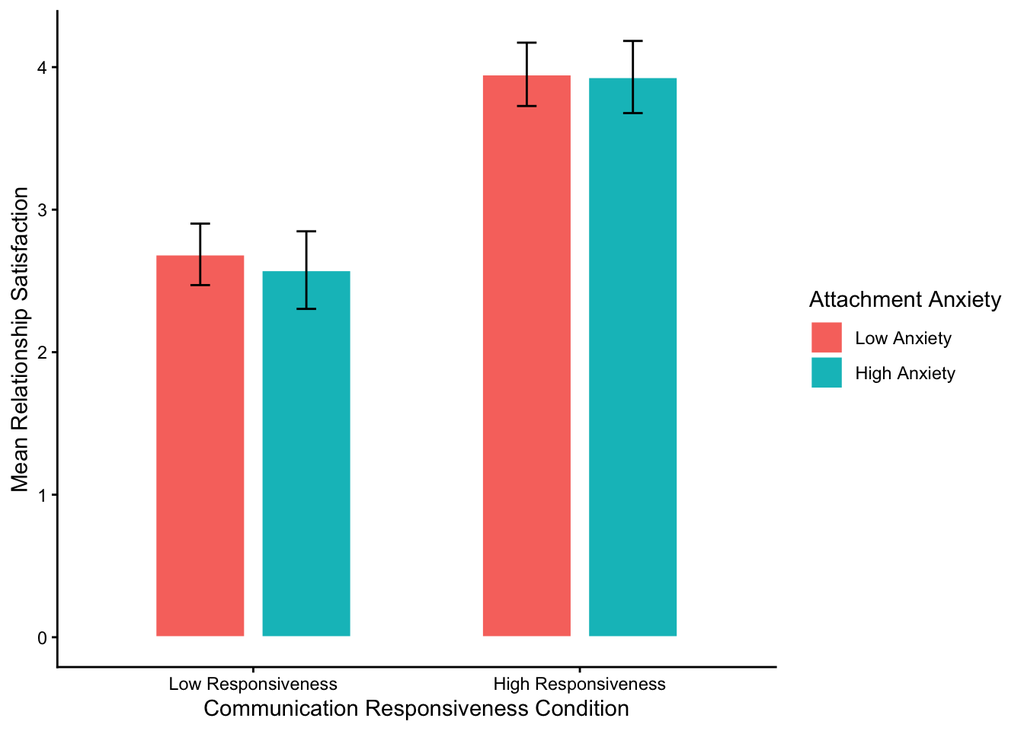

```r
p_bar <- ggplot(
  as.data.frame(
    emmeans(
      a1,
      ~ Condition * anxiety_msplit
    )
  ),
  aes(
    x = Condition,
    y = emmean,
    fill = anxiety_msplit
  )
) +
  geom_col(
    position = position_dodge(width = 0.65),
    width = 0.55,
    color = "white"
  ) +
  geom_errorbar(
    aes(
      ymin = lower.CL,
      ymax = upper.CL
    ),
    position = position_dodge(width = 0.65),
    width = 0.12
  ) +
  labs(
    x = "Communication Responsiveness Condition",
    y = "Mean Relationship Satisfaction",
    fill = "Attachment Anxiety"
  ) +
  theme_classic()

print(p_bar)
```

**Figure 1.** The graph shows a similar responsiveness pattern for participants with low and high attachment anxiety. In both groups, satisfaction was higher in the high-responsiveness condition.

**Save Figure**

```r
if (!dir.exists("figures")) {
  dir.create("figures")
}

ggsave(
  "figures/interaction_plot.svg",
  plot = p_bar,
  width = 7,
  height = 5
)
```

#### Analysis 2: Communication Responsiveness × Prior LDR Experience

The second ANOVA tested whether communication responsiveness and prior LDR experience were related to relationship satisfaction. Participants in the high-responsiveness condition reported higher satisfaction than participants in the low-responsiveness condition. Prior LDR experience was not significantly related to satisfaction, and it did not significantly change the effect of responsiveness.

```r
a2 <- afex::aov_ez(
  id = "id",
  dv = "relationship_satisfaction",
  data = study_data,
  between = c(
    "Condition",
    "Relationship_exp"
  )
)

a2
```

```
Anova Table (Type 3 tests)

Response: relationship_satisfaction
                      Effect     df  MSE         F  ges p.value
1                  Condition 1, 161 0.61 98.41 *** .379   <.001
2           Relationship_exp 1, 161 0.61      0.23 .001    .631
3 Condition:Relationship_exp 1, 161 0.61      1.78 .011    .184
---
Signif. codes:  0 '***' 0.001 '**' 0.01 '*' 0.05 '+' 0.1 ' ' 1
```

Communication responsiveness had a significant main effect, F(1, 161) = 98.41, p < .001, η²G = .379. Participants reported higher satisfaction in the high-responsiveness condition (M = 3.89, 95% CI [3.72, 4.07]) than in the low-responsiveness condition (M = 2.65, 95% CI [2.48, 2.83]). Prior LDR experience did not have a significant main effect, F(1, 161) = 0.23, p = .631, η²G = .001, and the interaction was not significant, F(1, 161) = 1.78, p = .184, η²G = .011. The responsiveness pattern was similar for participants with and without prior LDR experience.

**Marginal Means**

```r
emmeans(a2, ~ Condition)
```

```
 Condition           emmean     SE  df lower.CL upper.CL
 Low Responsiveness    2.65 0.0866 161     2.48     2.83
 High Responsiveness   3.89 0.0901 161     3.72     4.07

Results are averaged over the levels of: Relationship_exp
Confidence level used: 0.95
```

```r
emmeans(a2, ~ Relationship_exp)
```

```
 Relationship_exp emmean     SE  df lower.CL upper.CL
 0                  3.24 0.0950 161     3.06     3.43
 1                  3.30 0.0812 161     3.14     3.46

Results are averaged over the levels of: Condition
Confidence level used: 0.95
```

**Cell Means**

```r
cell_means_exp <- emmeans(
  a2,
  ~ Condition * Relationship_exp
)

cell_means_exp
```

```
 Condition           Relationship_exp emmean    SE  df lower.CL upper.CL
 Low Responsiveness  0                  2.71 0.120 161     2.47     2.94
 High Responsiveness 0                  3.78 0.147 161     3.49     4.07
 Low Responsiveness  1                  2.60 0.125 161     2.35     2.85
 High Responsiveness 1                  4.01 0.104 161     3.80     4.21

Confidence level used: 0.95
```

**Interaction Plot**

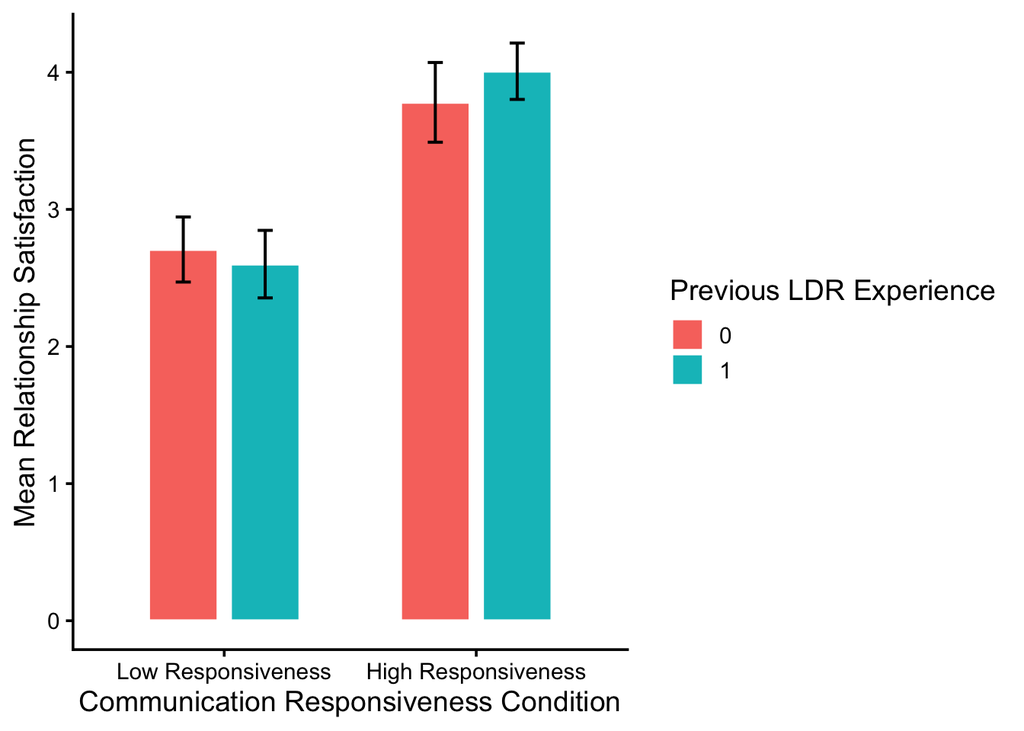

```r
p_exp <- ggplot(
  as.data.frame(cell_means_exp),
  aes(
    x = Condition,
    y = emmean,
    fill = Relationship_exp
  )
) +
  geom_col(
    position = position_dodge(width = 0.65),
    width = 0.55,
    color = "white"
  ) +
  geom_errorbar(
    aes(
      ymin = lower.CL,
      ymax = upper.CL
    ),
    position = position_dodge(width = 0.65),
    width = 0.12,
    linewidth = 0.7
  ) +
  labs(
    x = "Communication Responsiveness Condition",
    y = "Mean Relationship Satisfaction",
    fill = "Previous LDR Experience"
  ) +
  theme_classic(base_size = 14)

print(p_exp)
```

**Figure 2.** The graph shows a similar responsiveness pattern for participants with and without prior LDR experience. In both groups, satisfaction was higher in the high-responsiveness condition.

**Save Interaction Figure**

```r
if (!dir.exists("figures")) {
  dir.create("figures")
}

ggsave(
  "figures/ldr_experience_interaction_plot.svg",
  plot = p_exp,
  width = 7,
  height = 5
)
```

## Results Summary

The analyses showed that communication responsiveness was consistently related to relationship satisfaction. Participants who read the high-responsiveness vignette rated the imagined relationship more positively than participants who read the low-responsiveness vignette.

The first analysis examined whether this effect differed based on attachment anxiety. Communication responsiveness had a significant effect on relationship satisfaction. However, attachment anxiety did not have a significant main effect, and the interaction was not significant. This means that participants reported higher satisfaction in the high-responsiveness condition regardless of whether their attachment anxiety was low or high.

The second analysis examined whether this effect differed based on prior long-distance relationship experience. Communication responsiveness again had a significant effect on relationship satisfaction. Prior LDR experience did not have a significant main effect, and the interaction was not significant. This suggests that responsive communication was associated with higher satisfaction for participants with and without prior LDR experience.

Overall, the findings supported the hypothesis that high communication responsiveness would be related to greater relationship satisfaction. The moderation hypotheses were not supported.

## Reproducibility Information

This report was created using Quarto and R. The dataset is not published because it contains participant-level responses. The report includes the code used to import the dataset, prepare variables, calculate scale scores, run the analyses, and generate the figures.